# cRacle_BETA

### Then calculate the intersect of all taxa for each variable.

This is the Coexistence Likelihood Estimation.

```r
and = and_fun(densall)
```

### And find the optima for these joint likelihood functions.

```r
optim = get_optim(and)

print(optim$origk) #As implemented in Harbert and Nixon, 2015
```

```
##   bio1.origkde bio2.origkde bio3.origkde bio4.origkde bio5.origkde
## 1     96.30303     87.61290     30.77419     8715.038     281.0156
## 2     97.66667     88.12903     30.93842     8733.959     281.8895
##   bio6.origkde bio7.origkde bio8.origkde bio9.origkde bio10.origkde
## 1    -68.65689     353.5943     87.34409     186.1642      205.8240
## 2    -64.51222     355.6696     90.65591     187.8211      206.6276
##   bio11.origkde bio12.origkde bio13.origkde bio14.origkde bio15.origkde
## 1     -8.304985      1164.848      116.5269      79.61290      8.309873
## 2     -6.087977      1169.199      118.1398      80.29032      8.509286
##   bio16.origkde bio17.origkde bio18.origkde bio19.origkde
## 1      328.6188      254.7419      251.8856      291.0499
## 2      330.5073      255.9384      253.1417      293.8299
```

```r
print(optim$conintkde) #with 95% confidence intervals on the likelihood distribution.
```

```
##   bio1.cikde bio2.cikde bio3.cikde bio4.cikde bio5.cikde bio6.cikde
## 1   93.12121   86.00000   30.01173   8620.434   278.1026  -80.46921
## 2  112.21212   90.45161   31.44282   8823.833   292.3763  -57.05181
##   bio7.cikde bio8.cikde bio9.cikde bio10.cikde bio11.cikde bio12.cikde
## 1   345.8592   74.09677   179.5367    202.7439 -17.3577713    1144.176
## 2   363.0274  100.29032   199.7507    225.1085  -0.7302053    1192.047
##   bio13.cikde bio14.cikde bio15.cikde bio16.cikde bio17.cikde bio18.cikde
## 1    113.1935    77.38710    7.778104    317.5572    250.2551    247.1124
## 2    121.4731    82.51613    9.489736    336.1730    263.1173    258.9198
##   bio19.cikde
## 1    264.7937
## 2    301.5523
```

### And visualize (for Mean Annual Temperature):

multiplot() plots the object created by dens_obj(). addplot() plots a single element of dens_obj() (e.g. densall[[1]]) or a similar object created by the and_fun() function.

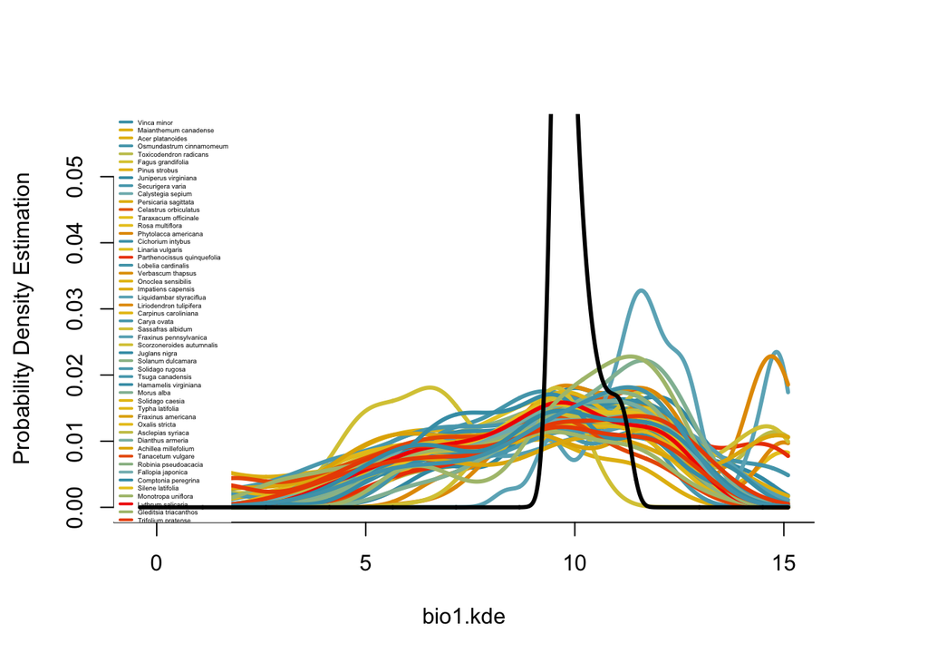

```r
n = 1
multiplot(densall, names(clim)[[n]], l.cex=0.3)
addplot(and, names(clim)[[n]], col = 'black')

abline(v = median(optim$origk[, n]), col = 'green') #Midpoint will be very close to the optimum. Original method of Harbert and Nixon, 2015 returned a top 1% range to introduce some slop
```

# cRacle performance

To see how well we have done with cRacle let’s have compare to the WorldClim model output as well as a summary of data from nearby weather stations from NOAA.

### Get NOAA data

```r
require(rnoaa);
```

```r
require(ggplot2);
station_data <- ghcnd_stations() # Takes a while to run (minutes)

lat_lon_df <- data.frame(id = 'locality',
                         latitude = c(site.coord[1]),
                         longitude = c(site.coord[2]))
nearby_stations <-  meteo_nearby_stations(lat_lon_df = lat_lon_df,
                                          #var = c('TMIN', 'TMAX', 'TAVG', 'PRCP'),
                                          station_data = station_data,
                                          radius = 10)
monitors <- nearby_stations$locality$id

all_monitors_clean <- meteo_pull_monitors(monitors) #get GHCN Data for each nearby station.


summary(all_monitors_clean);
```

```
##       id                 date                 prcp
##  Length:70963       Min.   :1893-01-01   Min.   :   0.00
##  Class :character   1st Qu.:1929-07-09   1st Qu.:   0.00
##  Mode  :character   Median :1954-03-19   Median :   0.00
##                     Mean   :1952-11-14   Mean   :  31.53
##                     3rd Qu.:1980-02-16   3rd Qu.:  13.00
##                     Max.   :2018-08-31   Max.   :2002.00
##                                          NA's   :1033
##       snow             snwd              wesd              wesf
##  Min.   :  0.00   Min.   :   0.00   Min.   :   0.00   Min.   :  0.0
##  1st Qu.:  0.00   1st Qu.:   0.00   1st Qu.:   0.00   1st Qu.:  0.0
##  Median :  0.00   Median :   0.00   Median :   0.00   Median :  0.0
##  Mean   :  2.34   Mean   :  16.59   Mean   :  13.74   Mean   : 32.9
##  3rd Qu.:  0.00   3rd Qu.:   0.00   3rd Qu.:   0.00   3rd Qu.: 18.5
##  Max.   :457.00   Max.   :1168.00   Max.   :1448.00   Max.   :394.0
##  NA's   :28562    NA's   :40660     NA's   :70258     NA's   :70871
##       dapr            dasf            mdpr            mdsf
##  Min.   :2.00    Min.   :2       Min.   : 18.0   Min.   :102.0
##  1st Qu.:2.00    1st Qu.:2       1st Qu.: 46.0   1st Qu.:113.2
##  Median :2.00    Median :2       Median : 94.0   Median :124.5
##  Mean   :2.45    Mean   :2       Mean   :102.8   Mean   :124.5
##  3rd Qu.:2.00    3rd Qu.:2       3rd Qu.:146.0   3rd Qu.:135.8
##  Max.   :7.00    Max.   :2       Max.   :284.0   Max.   :147.0
##  NA's   :70932   NA's   :70961   NA's   :70932   NA's   :70961
##       tmax             tmin              tobs              wt01
##  Min.   :-200.0   Min.   :-283.00   Min.   :-217.00   Min.   :1
##  1st Qu.:  72.0   1st Qu.: -22.00   1st Qu.:  11.00   1st Qu.:1
##  Median : 161.0   Median :  44.00   Median :  89.00   Median :1
##  Mean   : 158.9   Mean   :  43.37   Mean   :  86.47   Mean   :1
##  3rd Qu.: 244.0   3rd Qu.: 122.00   3rd Qu.: 167.00   3rd Qu.:1
##  Max.   : 400.0   Max.   : 300.00   Max.   :1206.00   Max.   :1
##  NA's   :30636    NA's   :30767     NA's   :45182     NA's   :70538
##       wt03            wt04            wt05            wt06
##  Min.   :1       Min.   :1       Min.   :1       Min.   :1
##  1st Qu.:1       1st Qu.:1       1st Qu.:1       1st Qu.:1
##  Median :1       Median :1       Median :1       Median :1
##  Mean   :1       Mean   :1       Mean   :1       Mean   :1
##  3rd Qu.:1       3rd Qu.:1       3rd Qu.:1       3rd Qu.:1
##  Max.   :1       Max.   :1       Max.   :1       Max.   :1
##  NA's   :70493   NA's   :70914   NA's   :70927   NA's   :70948
##       wt08            wt11            wt14            wt16
##  Min.   :1       Min.   :1       Min.   :1       Min.   :1
##  1st Qu.:1       1st Qu.:1       1st Qu.:1       1st Qu.:1
##  Median :1       Median :1       Median :1       Median :1
##  Mean   :1       Mean   :1       Mean   :1       Mean   :1
##  3rd Qu.:1       3rd Qu.:1       3rd Qu.:1       3rd Qu.:1
##  Max.   :1       Max.   :1       Max.   :1       Max.   :1
##  NA's   :70930   NA's   :70880   NA's   :70947   NA's   :68894
##       wt18
##  Min.   :1
##  1st Qu.:1
##  Median :1
##  Mean   :1
##  3rd Qu.:1
##  Max.   :1
##  NA's   :70537
```

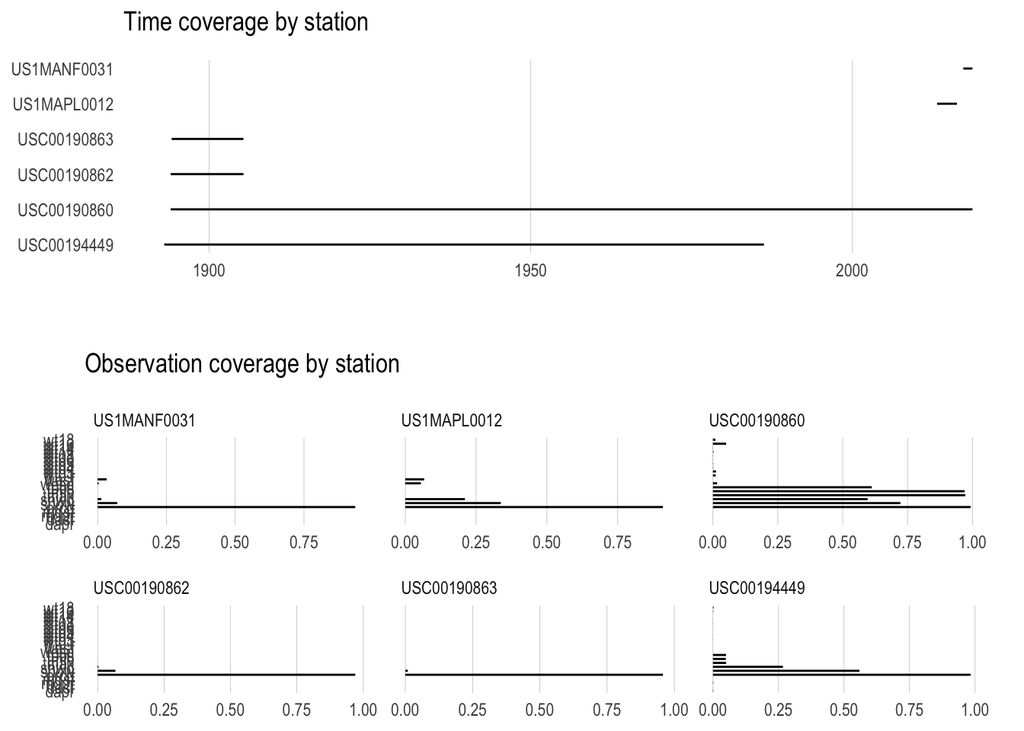

```r
#plot e.g.,
#plot(all_monitors_clean$date, (all_monitors_clean$tmax))

all_monitors_clean = all_monitors_clean[order(all_monitors_clean$date),]
coverage=meteo_coverage(all_monitors_clean)

autoplot(coverage)
```

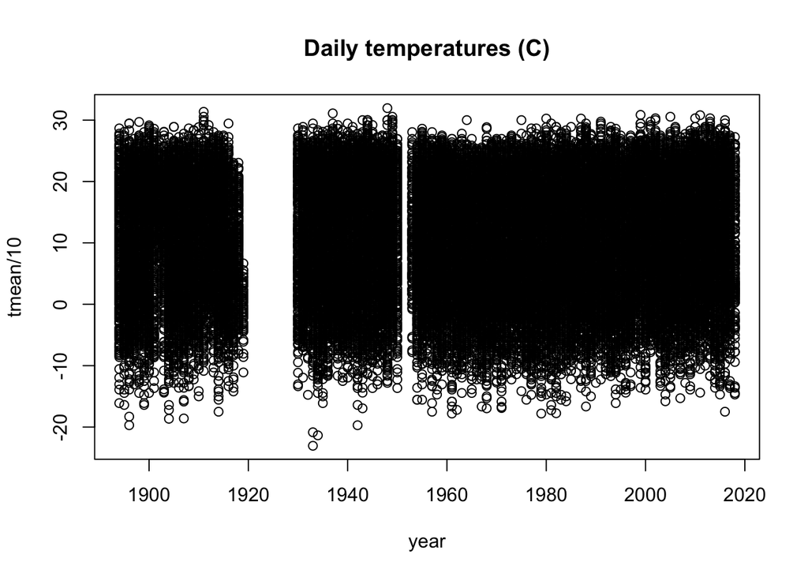

```r
best_cover = coverage[which(coverage$total_obs == max(coverage$total_obs)),]$id;
monitors_clean = subset(all_monitors_clean, all_monitors_clean$id == best_cover)
dates = monitors_clean$date
datestr = strsplit(as.character(dates), '-')
year = list();
for(i in 1:length(datestr)){
  year[[i]] = datestr[[i]][1];
}
year = unlist(year)
tmean = (monitors_clean$tmax + monitors_clean$tmin)/2

plot(year, tmean/10, main="Daily temperatures (C)")
```

```r
#summarize mean temperature profile
year.tmean = cbind(as.numeric(year), tmean/10)
m = vector(); z = 1;
for(i in min(year.tmean[,1]):(max(year.tmean[,1]))){
  m[z] = mean(as.numeric(year.tmean[which(year.tmean[,1] == i), 2]),
              na.rm=TRUE)
  z = z+1;
}

ghcn.mat = mean(m, na.rm=TRUE) #Mean Annual Temperature
```

### Get WorldClim data for locality

```r
ex = extract(clim, cbind(site.coord[2], site.coord[1])) #extract Worldclim for site
site.ex = cbind(loc.name, site.coord[2], site.coord[1], ex)
colnames(site.ex) = c('locality', 'lon', 'lat', names(clim))
```

### Plot comparison

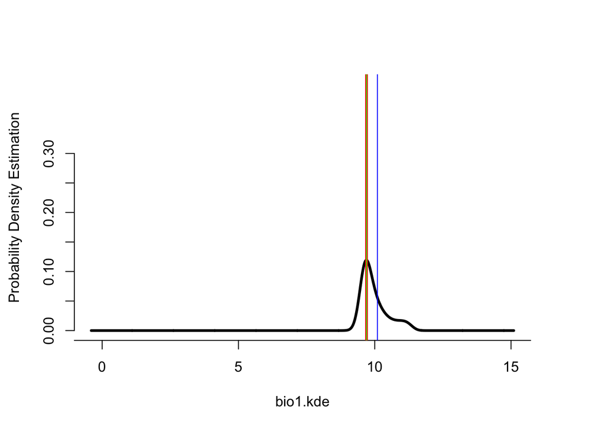

```r
densplot(and, names(clim[[1]]), col = 'black')
abline(v=median(optim$origk[,1])/10, col='red', lwd=3)
abline(v=ghcn.mat, col='blue')
abline(v=as.numeric(site.ex[,names(clim[[1]])])/10, col = 'green')
```

### Recap

The demonstration code above can be found at the cRacle github page: https://github.com/rsh249/cRacle/scripts/cRacle_beta.Rmd